# Unsupervised Clustering of Breast Cancer Samples

Lela Makharadze

## INTRODUCTION

Modern molecular cancer research is virtually inseparable from bioinformatical analysis and omic approaches are becoming common practice not only in academic but also diagnostic facilities [1].

Transcriptome and methylome analysis are some of the major tools for elucidating molecular profiles of different cancer types that in turn could lead to advancement in cancer treatment [2]. In order to facilitate these processes, a few publicly available databases collect a constantly increasing number of cancer samples. The Cancer Genome Atlas (TCGA) is one of such platforms that is frequently used for validation or reconsideration of common cancer classification, detection of biomarkers, assessing prognostic values of certain molecular profiles, etc. [3] [4].

Breast cancer is the most common type of cancer affecting women and the most frequent cause of cancer mortality in the same gender [5]. Defined by multiple criteria (such as immunohistochemistry, histopathology, molecular characteristics), all distinct subtypes can be still assigned to more general, hormone responsive and non-responsive groups which in turn determines the treatment course of a patient. Molecular classification has been subject to frequent refinement and more and more genes tend to be considered for diagnostic and treatment purposes [6]. Unsurprisingly, big data analysis has hugely contributed to these novelties in classification [7].

Having those uncertainties in mind, I set out to find out whether unsupervised clustering of RNAseq data could reveal distinct groups of samples from TCGA database and if so, which differentially expressed genes contribute most to the formation of these clusters. Additionally, I addressed methylation levels of the differentially expressed genes to test whether the epigenetic parameter could also reflect differences between samples.

# METHODS AND RESULTS

### Transcriptome data access

Using TCGAbiolinks package, RNAseq data from 500 samples were obtained from TCGA-BRCA project.

```r
#--------------------------------------------------------------------------------------------------------
                                         #gene expression
#--------------------------------------------------------------------------------------------------------
samples500 <- matchedMetExp("TCGA-BRCA", n = 500)
#matchedMetExp already considers data for the following methylation data access

query <- GDCquery(project = "TCGA-BRCA",
                  data.category = "Gene expression",
                  data.type = "Gene expression quantification",
                  experimental.strategy = "RNA-Seq",
                  platform = "Illumina HiSeq",
                  file.type = "results",
                  legacy = TRUE,
                  barcode = samples500)
GDCdownload(query)
geneexpr <- GDCprepare(query)
ExpMatrix <- assay(geneexpr) # es achvene dont run
```

### Principle Component Analysis and *k*-means Clustering

Principle Component Analysis (PCA) revealed two distinct clusters in TCGA breast cancer transcriptome data. As shown in Figure 1.B and C, PC2/PC3 form sharper clusters compared to PC1/PC2.

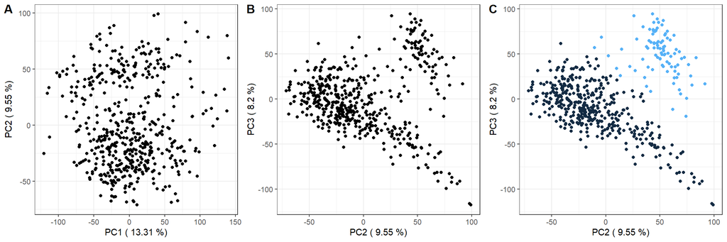

**Figure 1.** Cluster formation with **A.** PC1/PC2 and **B.** PC2/PC3. **C.** Sample assignment to two distinct clusters by k-means clustering

```r
ExpMatrixlog <- log(ExpMatrix+1)



ExpMatrixlogT <- as.data.frame(t(ExpMatrixlog))
pc <- prcomp(ExpMatrixlogT$)

ExpMatrixlogT$cluster
pc.sum <- summary(pc)$importance

varExp <- round(pc.sum[2, ] * 100, 2)  #for values to present on the axes

pcs <- data.frame(lables = rownames(pc$x), pc$x)  #dataframe for ggplot


p12 <- ggplot(data = pcs, aes(x = PC1, y = PC2, label = lables)) +
    geom_point() + xlab(paste("PC1 (", varExp[1], "%)")) + ylab(paste("PC2 (",
    varExp[2], "%)")) + theme_bw()



p23 <- ggplot(data = pcs, aes(x = PC2, y = PC3, label = lables)) +
    geom_point() + xlab(paste("PC2 (", varExp[2], "%)")) + ylab(paste("PC3 (",
    varExp[3], "%)")) + theme_bw()



results <- kmeans(pcs[, 3:5], 2) #thus told the function to pick PC2 (third column) to show me 2 clusters

kplot <- ggplot(data = pcs, aes(x = PC2, y = PC3, label = lables, col =results$cluster )) +
    geom_point() + xlab(paste("PC2 (", varExp[2], "%)")) + ylab(paste("PC3 (",
    varExp[3], "%)")) + theme_bw()
kplot+theme(legend.position = "none")

kp <- kplot+theme(legend.position = "none")

threeplots <-cowplot::plot_grid(p12, p23, kp,  align = "hv", nrow = 1, labels = c('A', 'B', "C"))
```

However, additional processing steps help normalize data and the first two PCs generate clearer clusters.

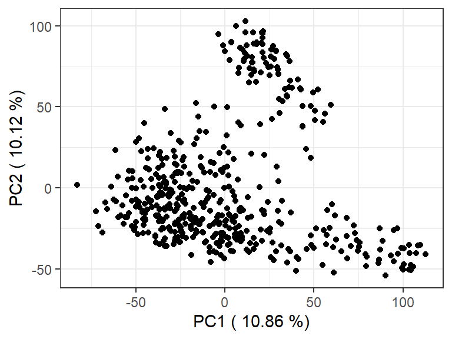

**Figure 2.** TCGAbiolink preprocessing and normalization procedures allow for defined cluster formation with PC1 and PC2, resembling Figure 1.B

```r
dataPrep <- TCGAanalyze_Preprocessing(object=geneexpr, #უნდა გამიგო რას აკეთეეეებს!!!
                                          cor.cut = 0.6,
                                          datatype = "raw_count",
                                          filename = "AAIC.png") #19947 500


dataNorm <- TCGAanalyze_Normalization(tabDF = dataPrep,
                                      geneInfo = TCGAbiolinks::geneInfo,
                                      method = "gcContent") #19866   500

ExpMatrixlog2 <- as.data.frame(log(dataNorm+1))
ExpMatrixlogT2<- as.data.frame(t(ExpMatrixlog2))
#created a function for PCA
PCA12 <- function(data) {

pc <- prcomp(data)
pc.sum <- summary(pc)$importance


varExp <- round(pc.sum[2, ] * 100, 2)

pcs <- data.frame(lables = rownames(pc$x), pc$x)


p12 <- ggplot(data = pcs, aes(x = PC1, y = PC2, label = lables)) +
    geom_point() + xlab(paste("PC1 (", varExp[1], "%)")) + ylab(paste("PC2 (",
    varExp[2], "%)")) + theme_bw()

print(p12)

}

#run PCA with the function with the normalized data
p12Norm <-PCA12(ExpMatrixlogT2)
#saveRDS(p12Norm, "p12Norm.rds")
#p12Norm <- read_rds("p12Norm.rds")
p12Norm
```

### Differential Gene Expression Analysis

Using limma package differential gene expression analysis (DEA) was conducted. The analysis allowed for identification of top up- and down-regulated genes depicted with the volcano plot.

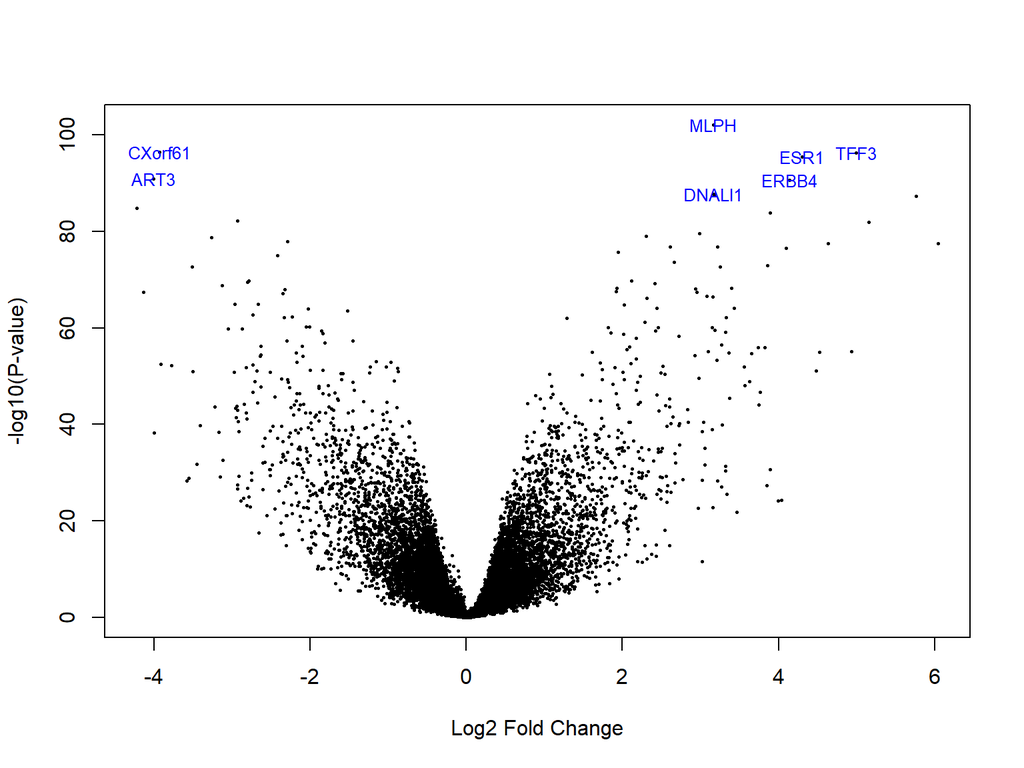

```r
#data modifications to add clusters to the expression matrix
colnames(ExpMatrixlogT) <- sub('\\|.*', '', colnames(ExpMatrixlogT)) # kept gene symbol and removed ENTREZ part from a gene name
ExpMatrixlogT$cluster <- as.numeric(results$cluster)
ExpMatrixlogUN <- as.data.frame(t(ExpMatrixlogT)) #transposed back.. now with cluster. this way required for limma

which( rownames(ExpMatrixlogUN)=="cluster" ) # 19948 - cluster row

# I tell the function about 2 groups and #exclude cluster IDs from calculation
groups <- as.factor(ExpMatrixlogUN[19948,])
designs <- model.matrix(~0 + groups, data=ExpMatrixlogUN[-19948,])


#Contrasts matrix
cms <- makeContrasts(difference = groups2-groups1, levels = designs)

fits <- lmFit(ExpMatrixlogUN[-19948,], designs)

vfits <- contrasts.fit(fits, contrasts=cms)

efits <- eBayes(vfits)

volcanoplot(efits, highlight = 7,  names = rownames(), hl.col = "blue")
```

### Pathway Enrichement Analysis

Using Reactome database, two major differentially expressed pathways were revealed.

```r
#change symbol names to entrez id
toptableIDs <-clusterProfiler::bitr(rownames(top.table), 'SYMBOL', 'ENTREZID', OrgDb=org.Hs.eg.db)

paths <- enrichPathway(gene=toptableIDs[,2], pvalueCutoff=0.05, readable=T)

knitr::kable(dd, format = 'html') %>% kable_material( "striped", "hover", "condensed")

#ReactomePA::dotplot(x, showCategory=5)
```

**Table 1.** Reactome Pathway assigned top differentially expressed genes to major ESR1 and ERBB4 mediated pathways

| Description | GeneRatio | geneID |
| --- | --- | --- |
| Estrogen-dependent gene expression | 5/8 | TFF3/ESR1/ERBB4/FOXA1/TFF1 |
| ESR-mediated signaling | 5/8 | TFF3/ESR1/ERBB4/FOXA1/TFF1 |
| Signaling by Nuclear Receptors | 5/8 | TFF3/ESR1/ERBB4/FOXA1/TFF1 |
| Nuclear signaling by ERBB4 | 2/8 | ESR1/ERBB4 |
| Signaling by ERBB4 | 2/8 | ESR1/ERBB4 |

### Methylation Data Access

Using MultipleAssayExperiment package, methylation data with the matched samples from the gene expression matrix was obtained.

```r
#--------------------------------------------------------------------------------------------------------
                                  #methylation data
#--------------------------------------------------------------------------------------------------------



querymeth500 <- GDCquery(project = "TCGA-BRCA",
                 data.category = "DNA methylation",
                 platform = "Illumina Human Methylation 450",
                 legacy = TRUE,
                 barcode = samples500) #sample500 is the variable from gene expression data access code

GDCdownload(querymeth500)
met500 <- GDCprepare(querymeth500, save = FALSE)
met500 <- met[rowSums(is.na(assay(met500))) == 0,]

metsub <- subset(met5001, subset = as.character(GenomicRanges::seqnames(met5001)) %in% c( "chr2", "chr4", "chr6", "chr7", "chr21")) #chromosomes chosen based on some top key DE gene chromosomal locations

#--------------------------------------------------------------------------------------------------------
                            #MATCHING TRANSCRIPTOM AND METHYLOM DATA SETS
#--------------------------------------------------------------------------------------------------------

rownames(exp) <- values(exp)$ensembl_gene_id  #matrix should receive ENSEMBLE IDs (ENSG)
mae <- createMAE(exp = assay(exp),
                 met = metsub,
                 save = TRUE,
                 linearize.exp = TRUE,
                 save.filename = "mae.rda",
                 met.platform = "450K",
                 genome = "hg19",
                 TCGA = TRUE)

maematrlist <- MultiAssayExperiment::assays(mae)
widematrix <-  wideFormat(mae)
maematrices <- as.matrix(widematrix) #gene expression and methylation matrices together
genesprobes <- as.data.frame(maematrices)
genesprobes1<- genesprobes[,-1] # sample IDs were in the first column not as row names
rownames(genesprobes1) <- genesprobes[,1] # made them as rownames
names(genesprobes1) = gsub(pattern = "DNA.methylation_", replacement = "", x = names(genesprobes1))
names(genesprobes1) = gsub(pattern = "Gene.expression_", replacement = "", x = names(genesprobes1))
```

**Table 2.** Matched samples for gene expression and methylation data

|  | cg00001747 | cg00001791 | ENSG00000041515 | ENSG00000041802 |
| --- | --- | --- | --- | --- |
| TCGA-E9-A1RI-11A | 0.0316556402705365 | 0.895185049591802 | 9.30606168942834 | 10.7731392067197 |
| TCGA-C8-A8HQ-01A | 0.357982778895716 | 0.849564878394551 | 5.4594316186373 | 11.6750749203854 |
| TCGA-BH-A0BJ-11A | 0.0148789045522333 | 0.909319446978672 | 3.90689059560852 | 11.4696418172395 |
| TCGA-OL-A66O-01A | 0.0340263776182061 | 0.904282511315165 | 2.58496250072116 | 11.57931593758 |

Several additional operations were required to find matching probes for the genes of interest to conduct downstream analyses.

```r
#probe and gene annotation data
annots = getAnnotation(IlluminaHumanMethylation450kanno.ilmn12.hg19)
annots <- as.matrix(annots)
#1 make a selection condition
tops <- topTable(efits, number=Inf) # get all genes from DEA
DOWNS <- tops[which(tops$logFC > 0), ] [1:20,] # up-reg top 20
UPS <- tops[which(tops$logFC < 0), ] [1:20,] # down-reg top 20
UN<- tops[which(tops$P.Value > 0.09 & tops$logFC < 0.5 & tops$logFC > -0.5) & tops$t < 1 & tops$t > -1,] %>% drop_na()

#first I filter data by chromosomes and then I pick gene names(string cause in annots several genes are pasted in a certain column) from  up and downregulated gene sets.  So I get a filtered annots matrix
ENSvecUNfinal <- dplyr::filter(annots, annots$chr==c( "chr2", "chr4", "chr6", "chr7", "chr21"))  %>% dplyr::filter(grepl(paste(rownames(UN[40:60,]), collapse="|"), UCSC_RefGene_Name))

#And then I turn it into a vector that containts only row names(=probe names) of that filtered annots matrix
vecUN <- rownames(ENSvecUNfinal) #36 probes

ENSvecUPfinal <- dplyr::filter(annots, annots$chr==c( "chr2", "chr4", "chr6", "chr7", "chr21")) %>% dplyr::filter(grepl(paste(rownames(UPS), collapse="|"), UCSC_RefGene_Name))
vecUPS <- rownames(ENSvecUPfinal) #66 probes

ENSvecDOWNfinal <- dplyr::filter(annots, annots$chr==c( "chr2", "chr4", "chr6", "chr7", "chr21")) %>% dplyr::filter(grepl(paste(rownames(DOWNS), collapse="|"), UCSC_RefGene_Name))
vecDOWNS <- rownames(ENSvecDOWNfinal) #43 probes

#I had to intersect probe names from annotation matrix to my dataframe as not all probes are found in mine. (სახელს შეცვლი.)
MatchitUN <-intersect(colnames(genesprobes1), vecUN)
MatchselectUN <- select_(genesprobes1, .dots = MatchitUN) #29  probes


MatchitUP <-intersect(colnames(genesprobes1), vecUPS)
MatchselectUP <- select_(genesprobes1, .dots = MatchitUP) #60 probes


MatchitDOWN <- intersect(colnames(genesprobes1), vecDOWNS)
MatchselectDOWN  <- select_(genesprobes1, .dots = MatchitDOWN) #36 probes



#binding all probes and calcuation of means per sample for each up-, down-regulated and unchanged gene probes.

MyProbes <- cbind(MatchselectUN, MatchselectUP, MatchselectDOWN)
MyProbes <- as.data.frame(sapply(MyProbes, as.numeric))
MyProbes$MeanProbeUN <- rowMeans(MyProbes[ , colnames(MatchselectUN)])
MyProbes$MeanProbeDOWN <- rowMeans(MyProbes[, colnames(MatchselectDOWN)])
MyProbes$MeanProbeUP <- rowMeans(MyProbes[, colnames(MatchselectUP)])

# sample names from geneexpression matrix have some extra numbers. removed them to correctly assign clusters
#to each patient. removing extra string does not hurt: sample names are still unique(no duplicates) and identical tu common matrix names.
rownames(ExpMatrixlogT)<-gsub('.{12}$', '', rownames(ExpMatrixlogT))
rownames(MyProbes) <- rownames(genesprobes1)


int <-intersect(rownames(MyProbes), rownames(ExpMatrixlogT))
ExpMatrixlogT1 <- subset(ExpMatrixlogT[int,]) # picked only those 497 samples out of 500 that are common
#in common df and gene expression matrix


#finally correct assignment of samples to clusters was possible
MyProbes$cluster <- as.factor(ExpMatrixlogT1$cluster)
```

### Methylation levels of ER+ and ER- groups

Comparing ERS1 levels between clusters allows for (still arbitrary) sample classification into ER- and ER+

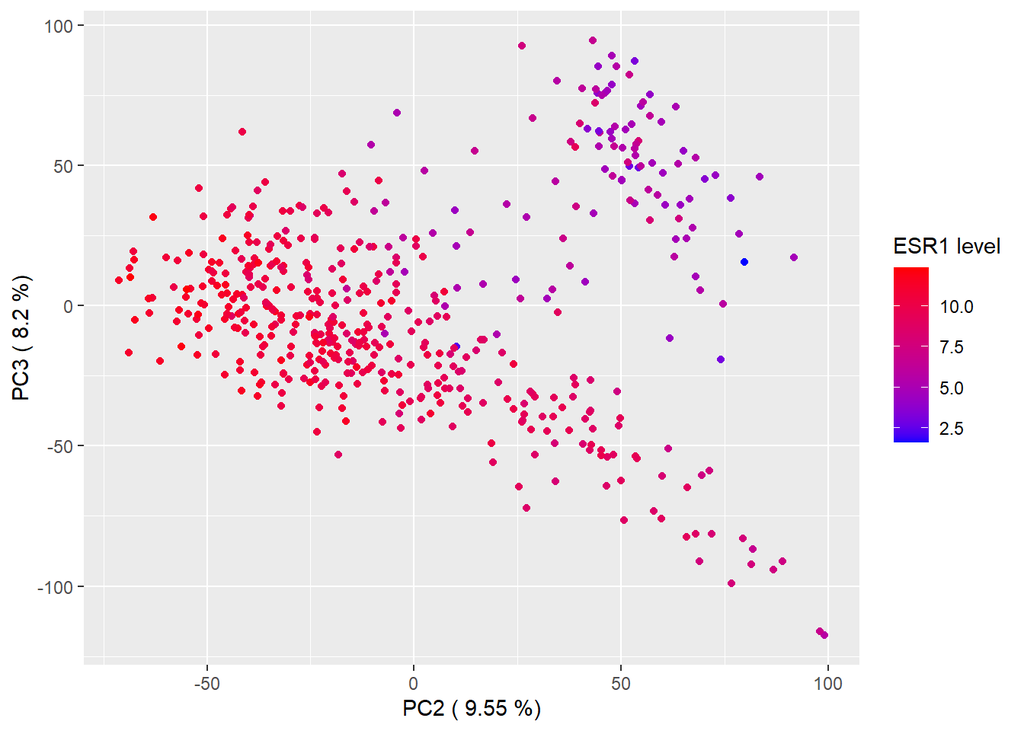

```r
 p23ER<- ggplot(data = pcs, aes(x = PC2, y = PC3, label = lables, color = ExpMatrixlogT$ESR1)) +
    geom_point() + xlab(paste("PC2 (", varExp[2], "%)")) + ylab(paste("PC3 (",
    varExp[3], "%)"))+scale_color_gradient(low="blue", high="red")+labs(color="ESR1 level")




p23ER
```

Methylation level of 20 up- and down-regulated genes show significant variation between ER- and ER+ clusters, whereas probes corresponding to the non-differentially expressed genes show no variance.

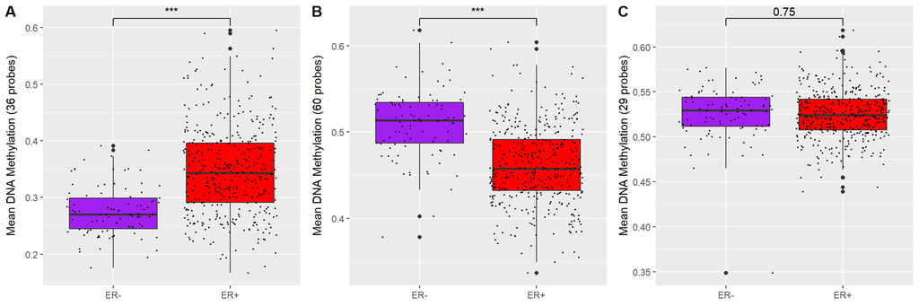

**Figure 5.** ER+ and ER- groups show distinct methylation levels. Groups are compared based on mean beta values from probes corresponding to 20 down-regulated **(A)**, up-regulated **(B)**, and non-differentially expressed **(C)** genes.

```r
MyProbes$cluster <- as.character(MyProbes$cluster)
MyProbes$cluster[MyProbes$cluster == "1"] <- "ER-"
MyProbes$cluster[MyProbes$cluster == "2"] <- "ER+"

UNbox <- MyProbes %>%ggplot(aes(x = cluster, y = MeanProbeUN, fill=cluster))
#stat_compare_means(method = "t.test", paired = FALSE)
 a <-UNbox + geom_boxplot()+geom_jitter(color="black", size=0.4, alpha=0.9) + geom_signif(test ="t.test", comparisons = list(c("ER+", "ER-")), map_signif_level=FALSE)+scale_fill_manual(values=c( "purple", "red"))+ theme(legend.position="none") +xlab(NULL) + ylab("Mean DNA Methylation (29 probes)")
UPbox <- MyProbes %>%ggplot(aes(x = cluster, y = MeanProbeUP, fill=cluster))  #stat_compare_means(method = "t.test")
b<-UPbox + geom_boxplot()+geom_jitter(color="black", size=0.4, alpha=0.9)+ geom_signif(test ="t.test", comparisons = list(c("ER+", "ER-")), map_signif_level=TRUE)+scale_fill_manual(values=c("purple", "red"))+ theme(legend.position="none") +xlab(NULL) + ylab("Mean DNA Methylation (36 probes)")

Downbox <- MyProbes %>%ggplot(aes(x = cluster, y = MeanProbeDOWN, fill=cluster))
c<- Downbox + geom_boxplot()+geom_jitter(color="black", size=0.4, alpha=0.9) + geom_signif(test ="t.test", comparisons = list(c("ER+", "ER-")), map_signif_level=TRUE)+scale_fill_manual(values=c("purple", "red")) + theme(legend.position="none") +xlab(NULL) + ylab("Mean DNA Methylation (60 probes)")




methboxp <- cowplot::plot_grid(b, c, a,  align = "hv", nrow = 1, labels = c('A', 'B', "C")) #rel_widths = 1, rel_heights =1)

methboxp
```